# **Introduction to Git and GitHub**

## **Main terminology**

**Git**: version control system that allows users work collaboratively on a codebase workflow to track changes and manage different versions of the files created during a codebase project. Git can be installed on a local machine and be used via the command line.

**GitHub:** a web-based platform that uses a graphical interface for Git that allows users to share, store, and collaborate remotely in public or private projects.

**GitHub Desktop:** Windows/macOS graphical interface for Git that allows users to perform Git commands without the command line interface.

**Repository:** a collection of files, folders, and version history managed by Git. A repository usually contains:

- The project files (of any type) and folders
- A hidden folder called “.git” that contains the metadata of the changes made in the codebase project
- All the commits, which represent a snapshot of the project files that were in the repository at a specific point in time. The commit objects also include a description of the changes made to the files.
- All the branches, which represent multiple versions of the codebase project and allow working in multiple features by different users at the same time.

**Initializing a repository:** Create a new local Git repository or initialize an existing directory.

**Staging:** Prepare the files to be committed to the repository.

**Committing:** Commit the changes to the repository (snapshot of the changes).

**Pushing:** Push the committed local files to the online repository. Updates the remote repository with the latest changes.

**Pulling:** Fetch the files of a remote repository to a local repository. Updates the local repository with the latest changes.

**Cloning:** Clone a remote repository to a local machine.

**Branching:** Create new/secondary versions of the repository. This allows working on new features of the codebase project without affecting the files that are in the main branch of the repository.

**Merging:** Merge the changes from one branch into another (usually to the main branch).

## **Getting Started with GitHub**

The first step to using GitHub is to create an account. Go to https://github.com and click on the "Sign up" button in the top right corner. Enter all the information required (i.e., email, username, password…) and click on "Create account".

## **Connecting to Git and GitHub Desktop**

As mentioned in the terminology, Git is a version control system that allows tracking and managing all changes made to codebase projects. To do so, you can use either Git, which is based on the command lines from the terminal, or use GitHub Desktop, which is a graphical (and more user-friendly) interface. The use of one or the other depends on which one you feel more comfortable with, but both are capable of performing the same tasks.

#### *GitHub Desktop*

You can download and install GitHub Desktop from https://desktop.github.com/. Once installed, open the software, and add your GitHub credentials (email and password) to connect to GitHub.

#### *Git*

Access https://git-scm.com/ to download and install Git. After installation, run the following commands to connect to your GitHub account:

`git config \--global user.name \'your name\'`

`git config \--global user.email \'your.email@finddx.org\'`

Please note, you may be asked for your GitHub password when pushing or pulling changes from a remote repository.

## **Creating a new repository (GitHub)**

It is possible to create a repository from either GitHub (recommended), GitHub Desktop, or Git (see “Creating a repository (GitHub Desktop and Git)” to do it using the last two approaches).

#### *GitHub*

To create a new repository on GitHub, click on the "New" button on the GitHub dashboard or go to the GitHub page of the organization you want to create a new repository, and on the “Overview” tab you should see a “New” button.

Once you click on new you should see the below image, where you need to give a name for the repository you are creating and an optional description. It is also possible to choose whether to make the repository public or private. Public repositories are visible to anyone, while private repositories can only be accessed by authorized collaborators. After this simply click on “Create repository”.

[figure not shown]

And you should see now an empty repository

[figure not shown]

It is also possible to create a repository in Git or GitHub Desktop, but after you create the repository, you will need to first commit and push the repository to a GitHub account. Thus, it is always easier to do this step first in GitHub directly and then simply clone the repository to a local machine.

## **Cloning the repository**

To be able to work on a repository that is available in GitHub, it is necessary to first clone the repository to a local machine. This will create a local copy (with the same folder name) of all the files that are available online, so a user can make any local modification of the files and code, and once the necessary modifications are made, push them into the GitHub remote repository.

To clone the repository, copy the URL that would appear on the new repository page.

[figure not shown]

Or if you want to clone a repository with existing files, click on the green "Code" button on the repository page, and then copy the URL.

[figure not shown]

#### *GitHub Desktop*

In GitHub Desktop simply go to “File” then “Clone repository” and paste the clipboard (GitHub repository address) in the “URL” tab that will appear in the popup window. You should also select the location (local path) where you want to store the repository and click on “Clone”. You can now go to the local path you chose, and you will see a folder with the name of the repository you cloned.

[figure not shown]

#### *Git*

Open the terminal and navigate to the directory where you want to store the project (cd /path to your directory/). Then, run:

`git clone \<paste the copied URL here\>`

For this example, would look something like this:

`git clone <https://github.com/finddx/githubTutorial.git>`

## **Creating a repository (GitHub Desktop and Git)**

As mentioned above, it is also possible to first create a local repository and then connect it to GitHub. The main difference between first creating the remote repository in GitHub with creating it directly on a local machine is that, unlike the first option, it is now no longer necessary to clone the repository because it is already in the local machine, but now it is necessary to connect the local repository with a GitHub account to create the remote repository.

#### *GitHub Desktop*

In GitHub Desktop you can create a repository simply by clicking on “File” and “New repository”, you will see a popup window like the one below to add basic information about the repository such as name, the location of the local repository, etc.

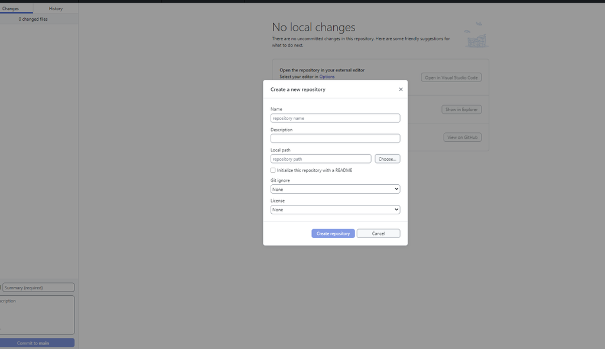

After creating a local repository you will see that you are now asked to publish the repository to GitHub.

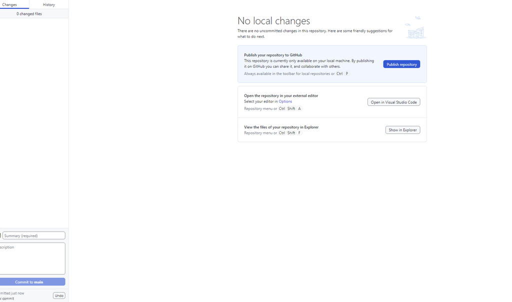

Click on “Publish repository” to link the repository to a GitHub account.

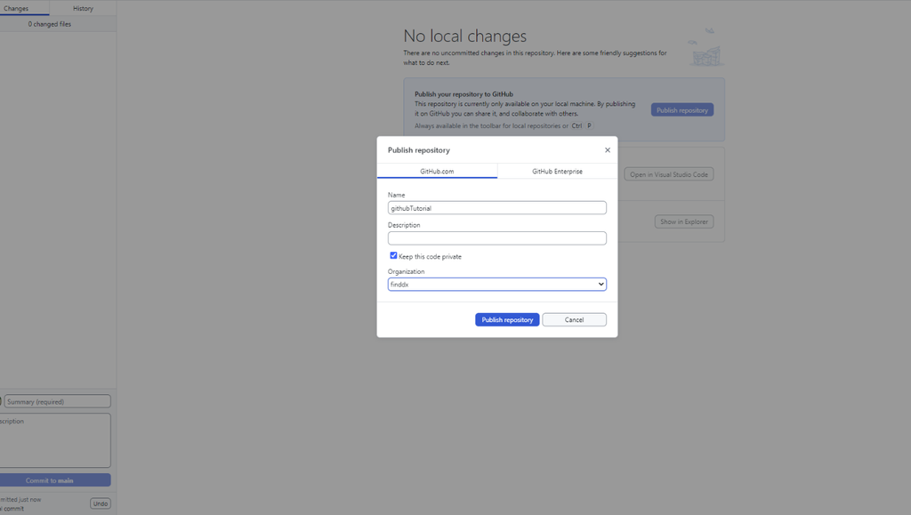

#### *Git*

To create a new Git repository, open the terminal (or command prompt) and navigate to the location where the repository will be locally created:

`cd /path to your directory/`

Then create a new directory for the repository (for this example, it is called “githubTutorial”):

`mkdir githubTutorial`

And navigate into the new directory to initialize a new Git repository:

`cd githubTutorial`

`git init`

Now it will be necessary to create a repository in GitHub (follow the steps from “Creating a new repository (GitHub)” until “Cloning a repository”) to connect it to the local repository. Please make sure that the names of the repositories in both Git and GitHub are the same, including lower- and upper-case letters.

Once the GitHub account is created will be necessary to copy the URL of the GitHub repository to Git and run the command below (again, in this example we are using a repository called githubTutorial that is stored in the FIND GitHub account):

`git remote add origin https://github.com/finddx/githubTutorial.git`

You should then verify that the “origin” remote has been added successfully:

`git remote -v`

If so, you should see something like this:

`origin https://github.com/your-username/githubTutorial.git (fetch)`

`origin https://github.com/your-username/githubTutorial.git (push)`

And then simply push the local repository to GitHub:

`git push -u origin main`

Note, depending on the GitHub repository, “main” could also be called “master” as the default branch.

## **Making changes to the repository**

Once there is a local copy of a repository in a local machine, it is now possible to start making changes to the code/files of the project. To do so, simply open the script or file and do the modifications you need to do. Once the work is finished save the new changes in the local repository you are working on. You can also create/add new files to the repository if you need to.

## **Committing changes**

Once the changes are made you need to stage and commit the changes so this can be moved to the GitHub repository too. The staging process refers to adding/preparing the files that will be committed to the repository. The commit stage refers to taking a “snapshot” of the changes that were made in the repository, so we can keep track of any modifications.

#### *GitHub Desktop*

In GitHub Desktop when there is no modifications the screen will look like the image below, indicating there are “No local changes”, you can also observe that the left area indicates “0 changed files”.

[figure not shown]

However, if we add a file or modify some pieces of the script, those will be highlighted in the screen (green for all the information we add, and red for the information we remove). For this example, we created a new R project called github_tutorial that holds a hello function that simply prints “Hello” + the name of the person. If we save this file, we will observe that everything is in green because there are now new files that did not exist before.

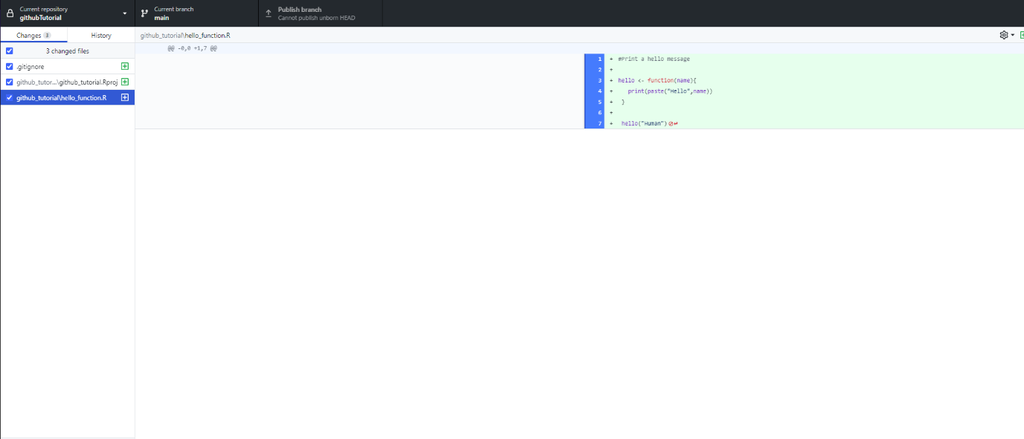

You can see that on the left area (image above) everything is automatically selected, this indicates that all the files are now in the staging phase, you can uncheck any boxes in case you do not want to stage (and commit) all the files.

We then can proceed to commit the file. First, write a message (in present tense) on the left-bottom area indicating the modifications that were made, and an optional description to detail everything you did, so all the users can better understand the changes that were made. In this example due to it is the first commit, we can put something like “Initial commit”. After this, click on “Commit to main” to commit the changes from the local repository to the remote repository in GitHub.

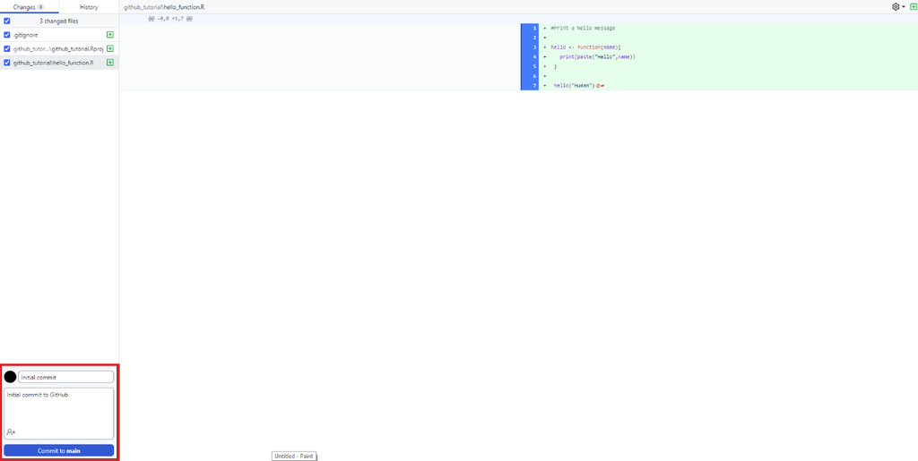

#### *Git*

To move all the files to stage mode in Git simply run:

`git add .`

Where “.” refers to selecting all the files, but you could also add specific files. For example, if you just want to move a file called “test.R” you could run this command:

`git add test.R`

After this, you could run git status just to verify that the files are in stage mode.

Once the desired files are in stage mode, you need to commit them. To do so, run the below command, note that you need to add a message (in present tense) to the commit indicating the changes that were made, so all the users that work on the project can relate to what the new changes refer to.

`git commit -m \"Add your commit message here\"`

## **Pushing changes to GitHub**

Once the files have been committed it is necessary to push them to GitHub, so all the new modifications can be visible to the users that have access to the repository.

#### *GitHub Desktop*

Once you commit the changes in GitHub Desktop, a new message will appear asking to push the changes to the remote repository, simply click on “Publish branch” to push the files to the remote repository. You can also observe that now it says “0 changed files”, as all of them are now committed.

[figure not shown]

If you now go to the GitHub repository, you will see the new files/changes and all the information about the commit (i.e., commit message, date of the commit, etc.).

[figure not shown]

#### *Git*

In Git, to push the local changes into the GitHub repository simply run the following command:

`git push origin main`

## **Pulling changes from GitHub**

It is common that when working on a collaborative repository, multiple users work and modify the files constantly. So, to keep track of the changes made by other users (or a file that is updated automatically), you need to pull those changes from the remote repository to the local machine you are working on before making a new modification.

For this example, assume there is another user working on the same repository who modified the hello function and added a welcome message after the hello sentence. To do that, the user first of course cloned the repository locally, and then committed and pushed the files to the remote repository, so now we can see in GitHub the changes that this person made.

[figure not shown]

#### *GitHub Desktop*

Whenever there are new changes in the GitHub repository, GitHub desktop would indicate there are committed changes that are not in the local machine (if you are sure there are new changes, but do not see any message in GitHub desktop simply click on “Fetch” in the ribbon area to update the connection). To get the newest changes from the remote repository to the local one, click on “Pull origin” and you will see that the new modifications/files are now added to the local repository.

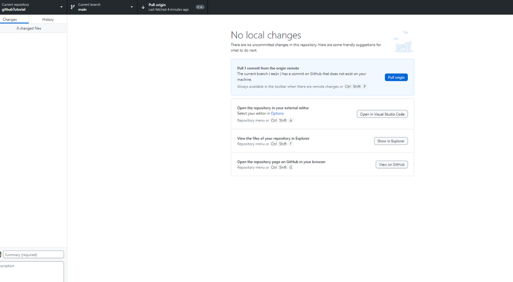

#### *Git*

In Git, to pull changes simply run:

`git pull origin main`

## **Working with branches**

Because GitHub is a collaborative platform, it may be cases when more than one person is working on the same file at the same time or when the new modifications need to be first validated by a third person to ensure everything works as expected. In those cases, it is necessary to push the new files and modifications into an independent “branch”, which basically is a clone of the main repository, plus the new modifications that were made in the local machine. In that way, if someone modifies something, the new modifications are in an independent branch and the software running is not affected until is fully tested and ensure modifications from other users are not overwritten until they have been tested or approved.

In GitHub, you can create an empty branch by clicking on the “main” branch filed and then a small window will pop up so you can put the name of the new branch.

[figure not shown]

#### *GitHub Desktop*

In GitHub Desktop you can simply go to “Current branch” in the upper ribbon area and click on “New branch”, from there put the name of the new branch and click on “Create branch”.

[figure not shown]

To create a new branch and add directly the new modifications, you need of course to have new changes that have not been committed yet. Let’s say we change the “Hello Human Welcome to FIND” sentence, so we include some exclamation signs and change the “W” to lower case, which will lead to the following message “Hello Human! Welcome to FIND!”. As you can see in the image below, GitHub will then highlight in red the pieces of code that will no longer exist and in green the pieces that were added. Pieces or files that were not changed will not be highlighted.

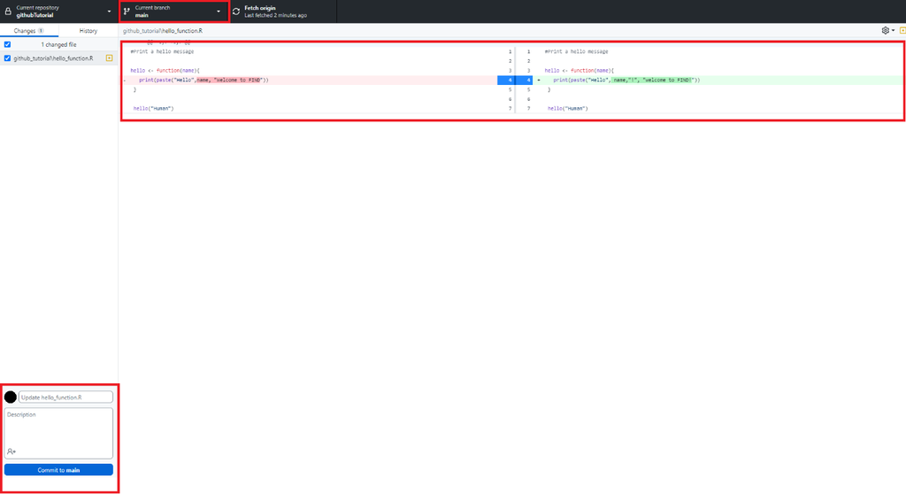

Then, you can of course commit those new changes to the remote repository, but before that, we need to create a new branch, so these new modifications do not overwrite anything from the main branch. In this example, we created a branch called “example-1”. To do that click on main (see image below) and type the name of the new branch and click on “Create new branch”.

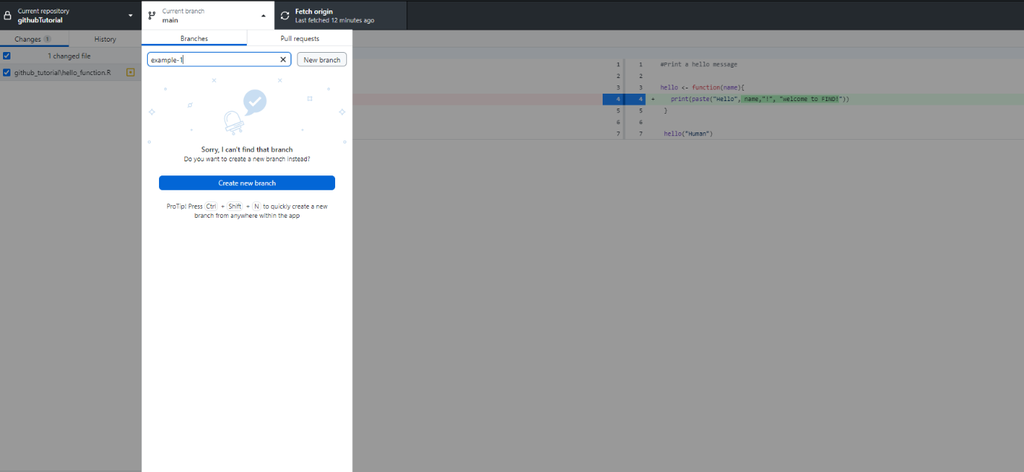

Select “Bring my changes to -name of the new branch-” and click on “Switch branch”

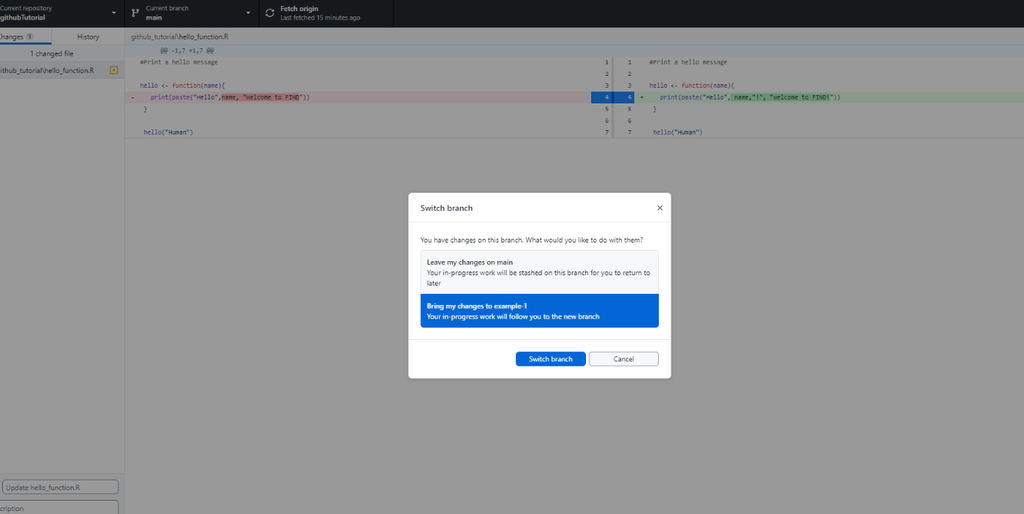

Now you will see that the current branch is set to the new branch name, and then you can commit and push the changes to the remote repository as we already saw in the corresponding section. If you now go to the GitHub repository you will see that the new branch is now live.

[figure not shown]

#### *Git*

In Git, there are two ways to create a new branch:

`git branch \<branch-name\>` creates a new branch, but it does not switch to it.

`git checkout -b \<branch-name\>` creates a new branch and switches to it.

But if you have already modified some files and want to switch and move those uncommitted changes directly to a new branch, run the following command:

`git switch -c \<branch-name\> -m`

## **Merging branches**

#### *GitHub*

Once you decided the information from the new branch is without issues and ready to be part of the main code, you can go to the GitHub repository and merge it to the “main” or “master” branch. Usually this is done by a third user, but it can also be made by the same user who created the new changes if the settings of the repository allow it. To merge a new branch with the main branch, go to the remote repository and you will see a message indicating “Compare & pull request” and simply click on it.

[figure not shown]

A new window will appear with several pieces of information (see image below). It will indicate whether those branches are “Able to merge” (i.e., there are no conflicts) and you will also be able to write a message (if any) about the merger process. Before clicking on “create pull request”, if you scroll down you will see that GitHub is comparing the modifications made as we previously saw when we created this new branch in GitHub Desktop (new additions are in green and deleted information is in red).

[figure not shown]

After clicking on “Create pull request”, a new window will appear validating this merge and if no issues arises, it would indicate there are not conflicts and you will be free to merge (“Merge pull request” button and then confirm merge).

[figure not shown]

Once the merging is finished, you will be asked if you want to delete the temporal branch, simply click on “Delete branch”.

[figure not shown]

Note that GitHub keeps track of any change, so if you click on the main branch field you can access all closed (and open) branches and restore them if necessary.

## **Merging a branch locally**

#### *GitHub Desktop*

To merge a branch locally, go to the branch (Current branch tab) where you want to merge another branch (usually main or master). Then click again in the “Current branch” tab and click on “Choose a branch to merge into -branch name-” .

[figure not shown]

Select the branch you want to merge into the current branch and click on “Create a merge commit”. Then, you can simply push the commit to the remote repository.

[figure not shown]

#### *Git*

In Git, it will be necessary to checkout the branch where you want to merge another branch (usually main or master) using the command `git checkout -branch name(main or master)-`, and run the merge command with the name of the branch you want to merge: `git merge -branch name to merge-`, for this example, would be: `git merge example-1`. Then, you will need to stage, commit, and push to the remote repository.

## **Dealing with conflicts**

Working in a collaborative project sometimes involves different users working on the same piece of code and coming up with different approaches for the same solution. This will of course create conflict because we would have two (or more) branches with different versions of the same file.

Sometimes, we can integrate the different solutions as part of the main project or use some parts of each solution to create a new one, but in most cases will be necessary to choose only want solution and remove others. Whatever the case, we need to take decisions and use just the part of the code we want to integrate into our main project.

#### *GitHub Desktop*

When there is a conflict, GitHub will immediately highlight these issues with the conflict markers: <<<<<<<HEAD “conflict code branch 1” ======= “conflict code branch 2” >>>>>> along with the name of the commit where the issue is present (see image below).

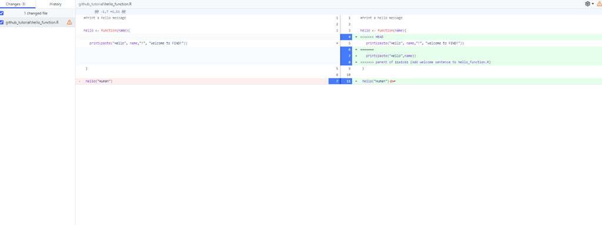

What you need to do is to open the file where there is a conflict; here for example: <<<<<<< HEAD print(paste("Hello", name,"!", "welcome to FIND!")) ======= print(paste("Hello",name)) >>>>>>> parent of 11a1c61 (Add welcome sentence to hello_function.R) }, and to solve it, we simply keep the piece of code we want to retain: print(paste("Hello", name,"!", "welcome to FIND!")) and remove the part of the script that we want to remove: <<<<<<< HEAD ======= print(paste("Hello",name)) >>>>>>> parent of 11a1c61 (Add welcome sentence to hello_function.R) }.

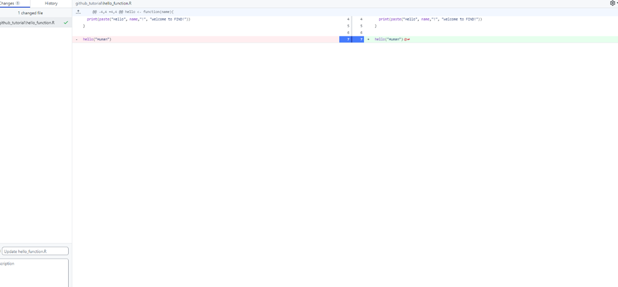

Then you will need to commit the new changes and push them to the remote repository as we already saw.

#### *Git*

In Git, you will need to identify the files that have conflict using `git status`, and as was mentioned for GitHub Desktop, open the conflicted file to look for the conflict markers (<<<<<<<HEAD “conflict code branch 1” ======= “conflict code branch 2” >>>>>>). Edit the file, keeping the piece of code you want to retain, and then simply stage, commit and push the changes to the remote repository.

## **Restoring a file on a specific commit (checkout)**

As mentioned throughout this tutorial, it is always possible to go back to a previous version of a commit in case the new version of the code does not work as expected or simply because you want to go back to a previous version for any specific reason.

#### *GitHub Desktop*

Go to the left sidebar and click on the “History” tab, right click on the commit you want to restore and click on “Revert changes in commit”. As you may see, it is also possible to create a new branch from a specific commit (Create branch from commit).

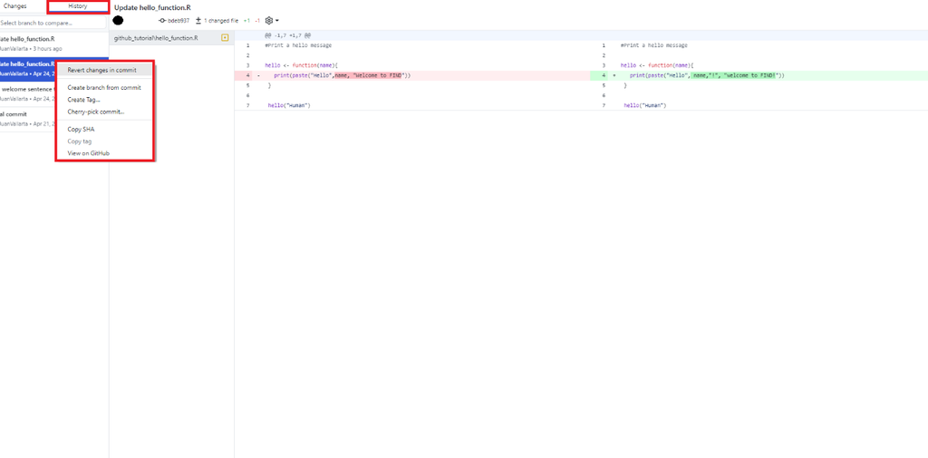

#### *Git*

In git, you would need to first find the “hash” (id) of the commit you want to restore, you can do this using:

`git log \-- file-name`

Then you need to use `git checkout commit-hash -- filename` to restore the file to the state on that specific commit.

Note that the “checkout” command is also used to switch between branches in Git (see Working with branches of this tutorial)